# Homework 1

Nicholas Esposito

9/15/2022

## Question 1

### Load in the data for Q1

```r
spdata <- read.csv("http://www.stat.ufl.edu/~winner/data/bioequiv_sulf.csv")
attach(spdata); #names(spdata)

library(knitr)
```

### P.1.A - See Written PDF for Work By-Hand

95% CI: (-177.61, 1177.09)

We can be 95% confident the mean difference of the Test formulation and the Reference formulation falls between -177.61 and 1177.09.

Since the test statistic, t = 1.4869, is less than the critical value, t(0.025,44) = 2.01537, we fail to reject the null hypothesis that µT - µR = 0.

```r
## Create a variable that is AUC for the drug sulfadoxine and a variable for formulation

AUC.sulf <- y[measure==2 & drug==1]       # measure=AUC, drug=sulfadoxine
form21 <- form[measure==2 & drug==1]               # form=1 if Test, form=2 if Ref
form.AUC.sulf <- factor(form21, levels=1:2, labels=c("T","R"))
cbind(form.AUC.sulf, AUC.sulf)
```

```
##       form.AUC.sulf  AUC.sulf
##  [1,]             1 11436.549
##  [2,]             1 10406.588
##  [3,]             1 12769.902
##  [4,]             1 10439.444
##  [5,]             1 13752.375
##  [6,]             1 12974.267
##  [7,]             1 10872.707
##  [8,]             1  9932.970
##  [9,]             1 10308.540
## [10,]             1 11458.121
## [11,]             1 10859.644
## [12,]             1 10739.787
## [13,]             1 10021.870
## [14,]             1 11099.313
```

[output cut: 32 more lines]

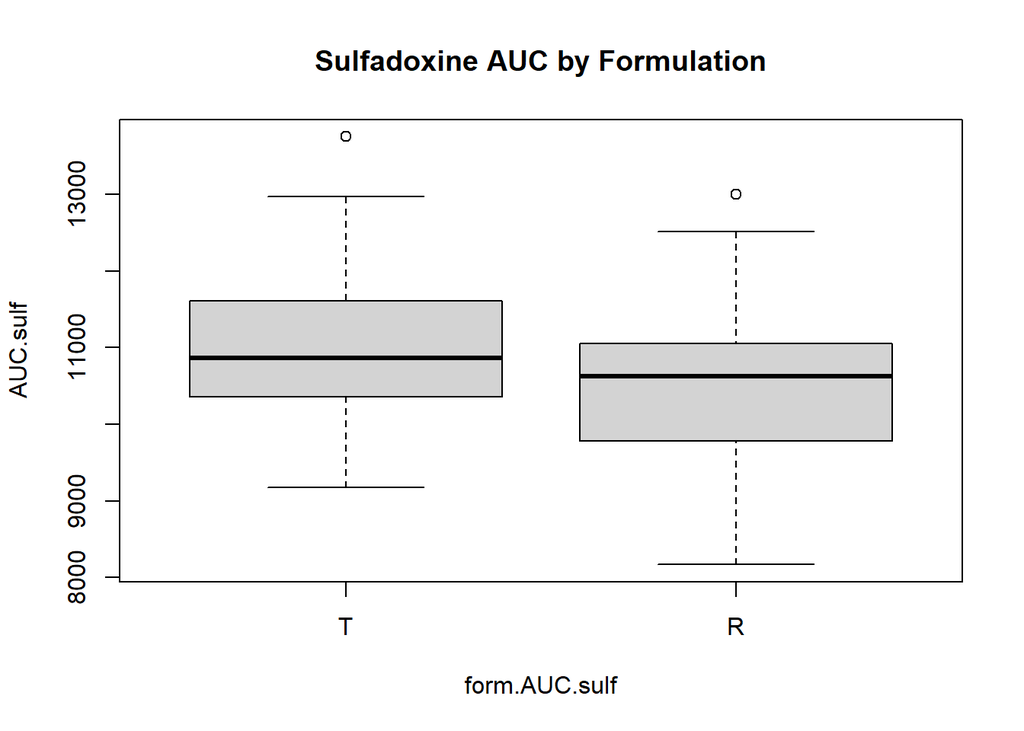

```r
plot(AUC.sulf ~ form.AUC.sulf, main="Sulfadoxine AUC by Formulation")
```

```r
## Compute n, ybar, sd for Test and Reference

n.T <- length(AUC.sulf[form.AUC.sulf=="T"])
n.R <- length(AUC.sulf[form.AUC.sulf=="R"])
ybarl.T <- mean(AUC.sulf[form.AUC.sulf=="T"])
ybarl.R <- mean(AUC.sulf[form.AUC.sulf=="R"])
sdl.T <- sd(AUC.sulf[form.AUC.sulf=="T"])
sdl.R <- sd(AUC.sulf[form.AUC.sulf=="R"])

## Print results in tabular form
T.stats <- cbind(n.T, ybarl.T, sdl.T)
R.stats <- cbind(n.R, ybarl.R, sdl.R)
TR.stats <- rbind(T.stats, R.stats)
colnames(TR.stats) <- c("n", "mean", "SD")
rownames(TR.stats) <- c("Test", "Reference")
round(TR.stats, 5)
```

```
##            n     mean      SD
## Test      23 11036.52 1142.27
## Reference 23 10536.78 1137.23
```

```r
## Compute pooled SD, 95%CI for muT-muR and print results

s_p <- sqrt(((n.T-1)*sdl.T^2+(n.R-1)*sdl.R^2)/(n.T+n.R-2))   # Pooled SD
df <- n.T+n.R-2                                              # Degrees of Freedom

ybarl.diff <- ybarl.T - ybarl.R                              # Mean Difference
se.diff <- s_p * sqrt(1/n.T + 1/n.R)                         # Standard Error of mean diff
t.025 <- qt(.975, df)                                          # Critical t-value for 95% CI

mul.LB <- ybarl.diff - t.025 * se.diff                        # Lower Confidence Limit
mul.UB <- ybarl.diff + t.025 * se.diff                        # Upper Confidence Limit

## Print out summary of 95%CI for muT-muR
ci.out <- cbind(df, s_p, ybarl.diff, se.diff, t.025, mul.LB, mul.UB)
colnames(ci.out) <- c("df","pooled SD", "mean diff", "Std Err", "t(.975)", "Lower Bound", "Upper Bound")
round(ci.out, 5)
```

```
##      df pooled SD mean diff  Std Err t(.975) Lower Bound Upper Bound
## [1,] 44  1139.753    499.74 336.0948 2.01537   -177.6145    1177.094
```

```r
## Use t.test function for 95%CI for µT-µR

AUC.ttest <- t.test(AUC.sulf ~ form.AUC.sulf, var.equal=TRUE, conf.level=0.95)
AUC.ttest
```

```
##
##  Two Sample t-test
##
## data:  AUC.sulf by form.AUC.sulf
## t = 1.4869, df = 44, p-value = 0.1442
## alternative hypothesis: true difference in means between group T and group R is not equal to 0
## 95 percent confidence interval:
##  -177.6145 1177.0945
## sample estimates:
## mean in group T mean in group R
##        11036.52        10536.78
```

### P.1.B - See Written PDF for Work By-Hand

95% CI: (0.4279, 2.3788)

We can be 95% confident the ratio σT^2 / σ_R^2 falls between 0.4279 and 2.3788.

Since the test statistic, F = 1.0089, is less than the critical value, F(0.975,22,22) = 2.358, we fail to reject the null hypothesis that σ_T^2 = σ_R^2.

```r
## Use var.test function for 95%CI for σ1^2/σ2^2

AUC.vartest <- var.test(AUC.sulf ~ form.AUC.sulf, var.equal=TRUE, conf.level=0.95)
AUC.vartest
```

```
##
##  F test to compare two variances
##
## data:  AUC.sulf by form.AUC.sulf
## F = 1.0089, num df = 22, denom df = 22, p-value = 0.9836
## alternative hypothesis: true ratio of variances is not equal to 1
## 95 percent confidence interval:
##  0.427877 2.378826
## sample estimates:
## ratio of variances
##           1.008883
```

### P.1.C - See Written PDF for Work By-Hand

β0 is the mean of Y (AUC value) where subjects receive the Reference formulation (X = 0).

β1 is the difference between the means (µT - µR).

µT can be found by adding β0 and β1.

When conducting the t-test for the H0: β1 = 0, we find the same test statistic (|t| = 1.4869) and the same p-value (0.1442) as the t-test in P.1.A.

```r
# Create var X to represent function for Test/Ref
X <- c(rep(1,23), rep(0,23))

lm_X <- lm(AUC.sulf ~ X)
summary(lm_X)
```

```
##
## Call:
## lm(formula = AUC.sulf ~ X)
##
## Residuals:
##     Min      1Q  Median      3Q     Max
## -2367.5  -703.5  -150.7   533.5  2715.8
##
## Coefficients:
##             Estimate Std. Error t value Pr(>|t|)
## (Intercept)  10536.8      237.7  44.336   <2e-16 ***
## X              499.7      336.1   1.487    0.144
## ---
## Signif. codes:  0 '***' 0.001 '**' 0.01 '*' 0.05 '.' 0.1 ' ' 1
##
## Residual standard error: 1140 on 44 degrees of freedom
## Multiple R-squared:  0.04784,    Adjusted R-squared:  0.0262
## F-statistic: 2.211 on 1 and 44 DF,  p-value: 0.1442
```

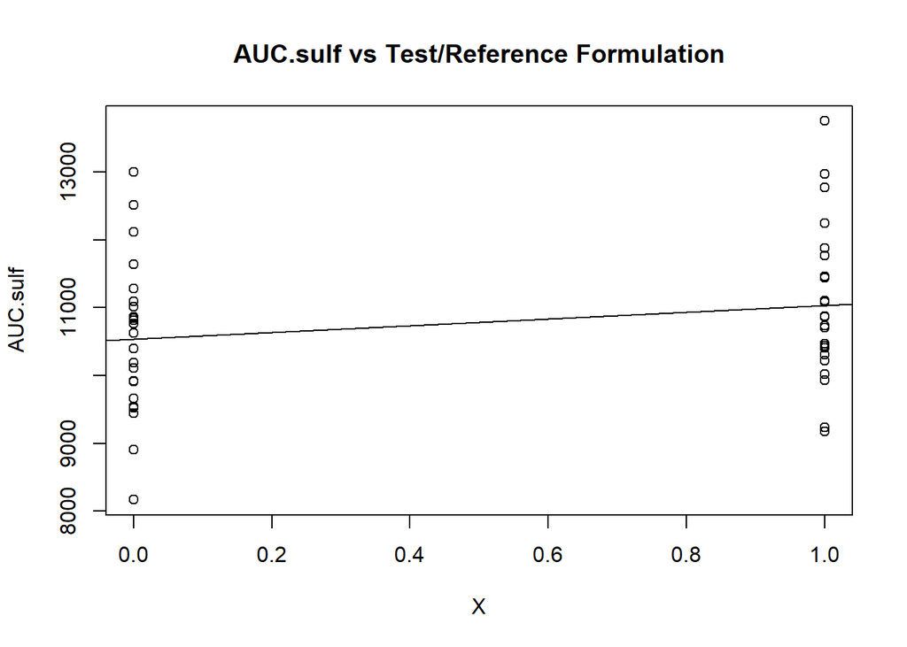

```r
plot(AUC.sulf ~ X, main="AUC.sulf vs Test/Reference Formulation")
abline(lm_X)
```

```r
X.ttest <- t.test(AUC.sulf ~ X, var.equal=TRUE, conf.level=0.95)
X.ttest
```

```
##
##  Two Sample t-test
##
## data:  AUC.sulf by X
## t = -1.4869, df = 44, p-value = 0.1442
## alternative hypothesis: true difference in means between group 0 and group 1 is not equal to 0
## 95 percent confidence interval:
##  -1177.0945   177.6145
## sample estimates:
## mean in group 0 mean in group 1
##        10536.78        11036.52
```

## Question 2 - See Written PDF for Work By-Hand

### All the work for Question 2 can be found in the written PDF.

## Question 3

### Read in the data for Q3

```r
# Read in data
spain_latlong <- read.csv(
  "https://users.stat.ufl.edu/~winner/data/spain_latlong.csv")
attach(spain_latlong); #names(spain_latlong)
head(spain_latlong)
```

```
##   Long_ptol  Long_wgs Lat_ptol  Lat_wgs
## 1  18.91593 3.0373984 44.40133 42.46950
## 2  18.76106 2.8813008 44.43459 42.66913
## 3  17.98673 2.5691057 44.33481 42.85213
## 4  17.19027 1.8926829 43.93570 42.93530
## 5  16.41593 0.9560976 43.92461 42.31978
## 6  15.61947 0.4357724 43.70288 42.68577
```

```r
tail(spain_latlong)
```

```
##    Long_ptol  Long_wgs Lat_ptol  Lat_wgs
## 43  5.995575 -8.565854 38.32594 37.46211
## 44  6.438053 -8.852033 38.32594 37.82810
## 45  6.548673 -7.655285 38.83592 38.14418
## 46  6.991150 -8.071545 38.94678 37.89464
## 47  7.433628 -7.733333 39.06874 38.46026
## 48  7.676991 -8.591870 39.50111 38.74307
```

### P.3.A - Obtain scatterplots of WGS ref - GIS - (Y) versus Ptolemy (X) for lat and long

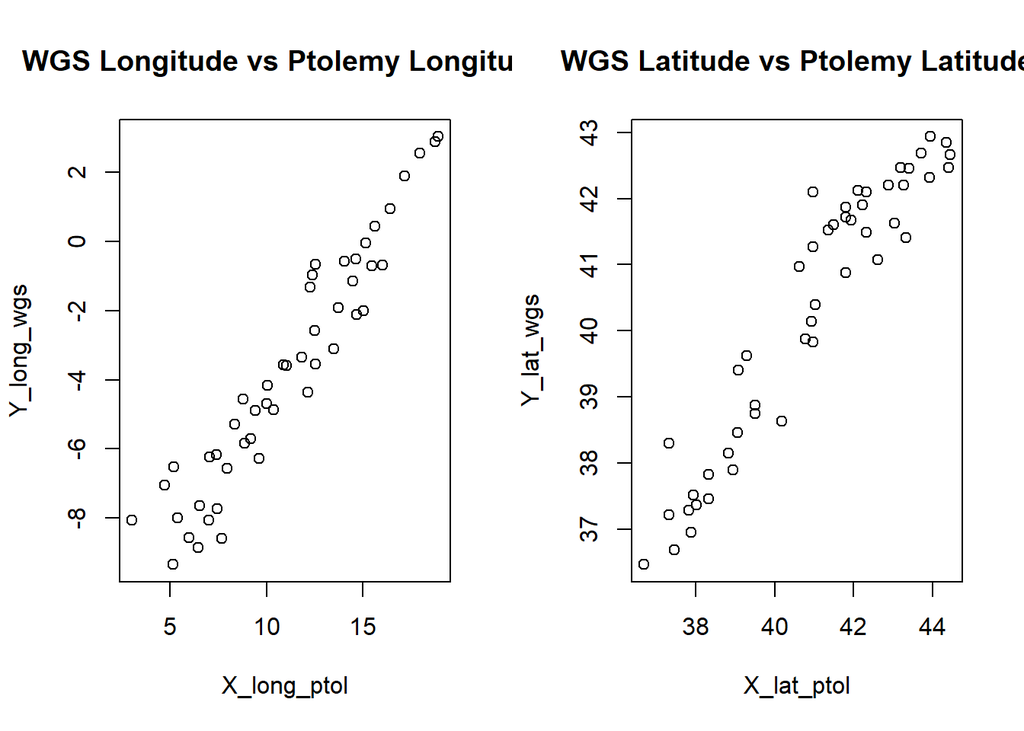

```r
# Define X and Y for lat and long
Y_long_wgs <- Long_wgs
X_long_ptol <- Long_ptol
Y_lat_wgs <- Lat_wgs
X_lat_ptol <- Lat_ptol

# Plots for Y versus X (lat and long)
par(mfrow=c(1,2))

plot(Y_long_wgs ~ X_long_ptol, main="WGS Longitude vs Ptolemy Longitude")

plot(Y_lat_wgs ~ X_lat_ptol, main="WGS Latitude vs Ptolemy Latitude")
```

### P.3.B - Fit simple linear regression models, relating GIS (Y) to Ptolemy (X)

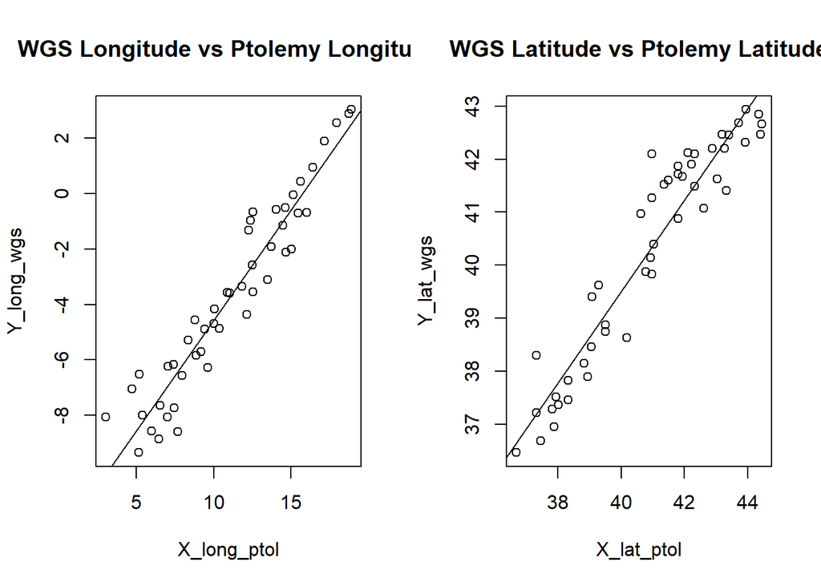

```r
# Fit linear models
lm_long <- lm(Y_long_wgs ~ X_long_ptol)
lm_lat <- lm(Y_lat_wgs ~ X_lat_ptol)

# Plot scatterplots again, now with linear models fitted
par(mfrow=c(1,2))

plot(Y_long_wgs ~ X_long_ptol, main="WGS Longitude vs Ptolemy Longitude")
abline(lm_long)

plot(Y_lat_wgs ~ X_lat_ptol, main="WGS Latitude vs Ptolemy Latitude")
abline(lm_lat)
```

### P.3.C - Test whether there is a positive association between GIS and Ptolemy

#### WGS Longitude (GIS) vs Ptolemy Longitude

H0: β1 <= 0, Ha: β1 > 0

Since we have a p-value that is very small (<2e-16), we reject the null hypothesis. Therefore, there is a positive association between WGS Longitude (GIS) and Ptolemy Longitude.

```r
summary(lm_long)
```

```
##
## Call:
## lm(formula = Y_long_wgs ~ X_long_ptol)
##
## Residuals:
##      Min       1Q   Median       3Q      Max
## -2.17142 -0.82974  0.06034  0.55848  2.05949
##
## Coefficients:
##              Estimate Std. Error t value Pr(>|t|)
## (Intercept) -12.52269    0.43079  -29.07   <2e-16 ***
## X_long_ptol   0.79487    0.03654   21.75   <2e-16 ***
## ---
## Signif. codes:  0 '***' 0.001 '**' 0.01 '*' 0.05 '.' 0.1 ' ' 1
##
## Residual standard error: 1.026 on 46 degrees of freedom
## Multiple R-squared:  0.9114, Adjusted R-squared:  0.9095
## F-statistic: 473.3 on 1 and 46 DF,  p-value: < 2.2e-16
```

#### WGS Latitude (GIS) vs Ptolemy Latitude

H0: β1 <= 0, Ha: β1 > 0

Since we have a p-value that is very small (<2e-16), we reject the null hypothesis. Therefore, there is a positive association between WGS Latitude (GIS) and Ptolemy Latitude.

```r
summary(lm_lat)
```

```
##
## Call:
## lm(formula = Y_lat_wgs ~ X_lat_ptol)
##
## Residuals:
##     Min      1Q  Median      3Q     Max
## -1.0364 -0.4388 -0.1698  0.5240  1.7681
##
## Coefficients:
##             Estimate Std. Error t value Pr(>|t|)
## (Intercept)  4.84465    1.69783   2.853  0.00646 **
## X_lat_ptol   0.86638    0.04145  20.904  < 2e-16 ***
## ---
## Signif. codes:  0 '***' 0.001 '**' 0.01 '*' 0.05 '.' 0.1 ' ' 1
##
## Residual standard error: 0.6335 on 46 degrees of freedom
## Multiple R-squared:  0.9048, Adjusted R-squared:  0.9027
## F-statistic:   437 on 1 and 46 DF,  p-value: < 2.2e-16
```

### P.3.D - C95% for β1 > 0

#### Linear model for WGS Longitude (GIS) vs Ptolemy Longitude

The 95% confidence interval for β1 is (0.7213,0.8684).

We are 95% confident the true value for β1 (the mean change) falls between 0.7213 and 0.8684.

Since the interval does not contain 0, we can say the mean change in GIS as Ptolemy is “increased by 1 unit”, or that the mean change is positive.

```r
confint(lm_long)
```

```
##                   2.5 %      97.5 %
## (Intercept) -13.3898306 -11.6555476
## X_long_ptol   0.7213281   0.8684198
```

#### Linear model for WGS Latitude (GIS) vs Ptolemy Latitude

The 95% confidence interval for β1 is (0.7830,0.9498).

We are 95% confident the true value for β1 (the mean change) falls between 0.7830 and 0.9498.

Since the interval does not contain 0, we can say the mean change in GIS as Ptolemy is “increased by 1 unit”, or that the mean change is positive.

```r
confint(lm_lat)
```

```
##                 2.5 %    97.5 %
## (Intercept) 1.4270933 8.2622007
## X_lat_ptol  0.7829506 0.9498045
```

### P.3.E ANOVAs, F-tests, coefficients of correlation and determination

#### Linear model for WGS Longitude (GIS) vs Ptolemy Longitude

Coefficient of correlation: 0.9546814

Coefficient of determination: 0.9114167

H0: σ1^2 / σ2^2 = 1, Ha: σ1^2 / σ2^2 != 1

```r
# Linear model for longitude
anova(lm_long)
```

```
## Analysis of Variance Table
##
## Response: Y_long_wgs
##             Df Sum Sq Mean Sq F value    Pr(>F)
## X_long_ptol  1 497.81  497.81  473.29 < 2.2e-16 ***
## Residuals   46  48.38    1.05
## ---
## Signif. codes:  0 '***' 0.001 '**' 0.01 '*' 0.05 '.' 0.1 ' ' 1
```

```r
aov(Y_long_wgs ~ X_long_ptol)
```

```
## Call:
##    aov(formula = Y_long_wgs ~ X_long_ptol)
##
## Terms:
##                 X_long_ptol Residuals
## Sum of Squares     497.8068   48.3833
## Deg. of Freedom           1        46
##
## Residual standard error: 1.025579
## Estimated effects may be unbalanced
```

```r
cor(X_long_ptol, Y_long_wgs) # X, Y
```

```
## [1] 0.9546814
```

```r
# R-squared (coeff. of determination)
summary(lm_long)$r.squared
```

```
## [1] 0.9114167
```

```r
# F-test
long.var.test <- var.test(X_long_ptol, Y_long_wgs, var.equal=TRUE, conf.level=0.95) # X, Y
long.var.test
```

```
##
##  F test to compare two variances
##
## data:  X_long_ptol and Y_long_wgs
## F = 1.4425, num df = 47, denom df = 47, p-value = 0.2128
## alternative hypothesis: true ratio of variances is not equal to 1
## 95 percent confidence interval:
##  0.8086536 2.5732284
## sample estimates:
## ratio of variances
##           1.442515
```

#### Linear model for WGS Latitude (GIS) vs Ptolemy Latitude

Coefficient of correlation: 0.9511858

Coefficient of determination: 0.9047545

H0: σ1^2 / σ2^2 = 1, Ha: σ1^2 / σ2^2 != 1

```r
# Linear model for latitude
anova(lm_lat)
```

```
## Analysis of Variance Table
##
## Response: Y_lat_wgs
##            Df  Sum Sq Mean Sq F value    Pr(>F)
## X_lat_ptol  1 175.382 175.382  436.96 < 2.2e-16 ***
## Residuals  46  18.463   0.401
## ---
## Signif. codes:  0 '***' 0.001 '**' 0.01 '*' 0.05 '.' 0.1 ' ' 1
```

```r
aov(Y_lat_wgs ~ X_lat_ptol)
```

```
## Call:
##    aov(formula = Y_lat_wgs ~ X_lat_ptol)
##
## Terms:
##                 X_lat_ptol Residuals
## Sum of Squares   175.38220  18.46287
## Deg. of Freedom          1        46
##
## Residual standard error: 0.6335351
## Estimated effects may be unbalanced
```

```r
cor(X_lat_ptol, Y_lat_wgs) # X, Y
```

```
## [1] 0.9511858
```

```r
# R-squared (coeff. of determination)
summary(lm_lat)$r.squared
```

```
## [1] 0.9047545
```

```r
# F-test
lat.var.test <- var.test(X_lat_ptol, Y_lat_wgs, var.equal=TRUE, conf.level=0.95) # X, Y
lat.var.test
```

```
##
##  F test to compare two variances
##
## data:  X_lat_ptol and Y_lat_wgs
## F = 1.2054, num df = 47, denom df = 47, p-value = 0.5245
## alternative hypothesis: true ratio of variances is not equal to 1
## 95 percent confidence interval:
##  0.675707 2.150177
## sample estimates:
## ratio of variances
##           1.205359
```